##1. Reading and modifying the DATA

```r
setwd("D:/Akhil/course_era/R/C5/W2")
x0 <- read.csv("activity.csv")
x0 <- na.omit(x0)
x0[,2] <- as.Date(x0[,2])
```

##2.Histogram of the total number of steps taken each day

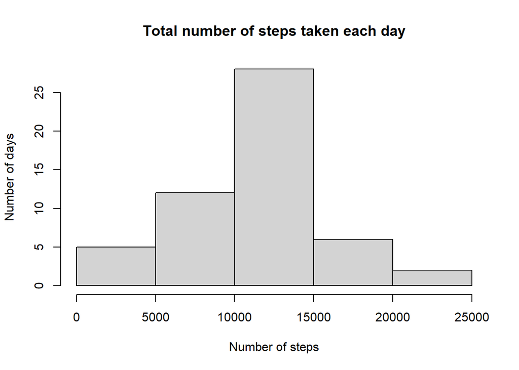

```r
library(dplyr)
x <- group_by(x0, date)
y <- summarize(x, sum(steps))

hist(y$`sum(steps)`, ylab = "Number of days", xlab = "Number of steps",
     main = "Total number of steps taken each day")
```

##3. Mean and median number of steps taken each day

```r
library(dplyr)
x <- group_by(x0, date)
meannmedian <- summarize(x, mean(steps), median(steps))
meannmedian
```

```
## # A tibble: 53 x 3
##    date       `mean(steps)` `median(steps)`
##    <date>             <dbl>           <dbl>
##  1 2012-10-02         0.438               0
##  2 2012-10-03        39.4                 0
##  3 2012-10-04        42.1                 0
##  4 2012-10-05        46.2                 0
##  5 2012-10-06        53.5                 0
##  6 2012-10-07        38.2                 0
##  7 2012-10-09        44.5                 0
##  8 2012-10-10        34.4                 0
##  9 2012-10-11        35.8                 0
## 10 2012-10-12        60.4                 0
## # ... with 43 more rows
```

##4. Time series plot of the average number of steps taken

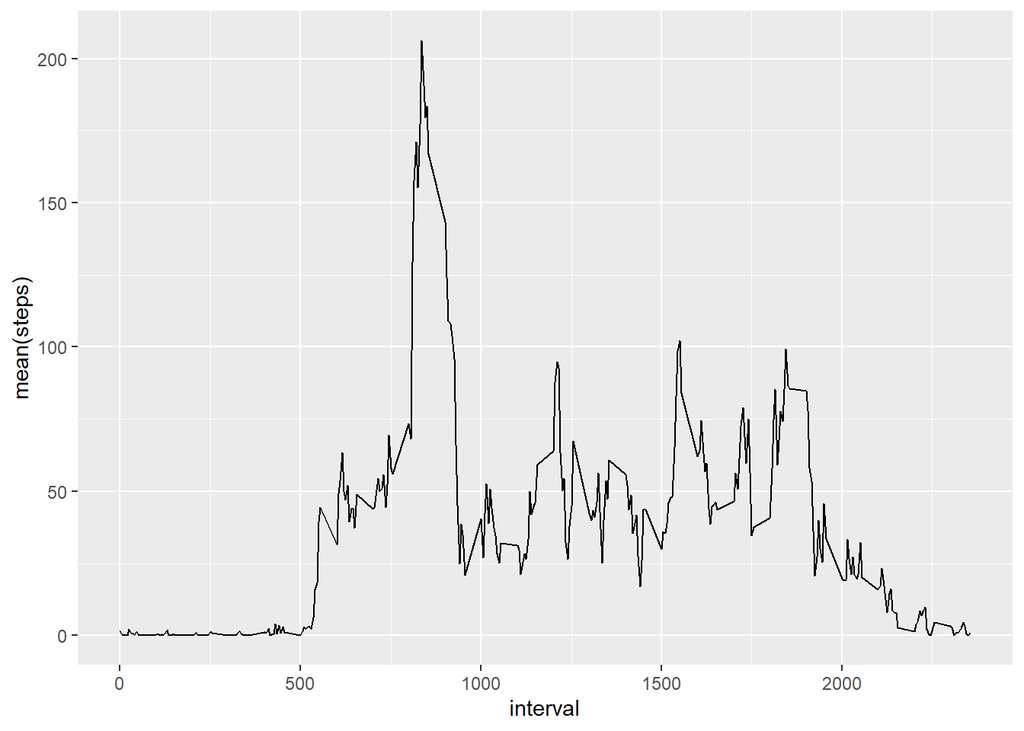

```r
library(dplyr)
x <- group_by(x0, interval)
y <- summarize(x, mean(steps))

library("ggplot2")
qplot(interval, `mean(steps)`, data = y, geom = "line")
```

```r
library(dplyr)
x <- group_by(x0, interval)
y <- summarize(x, mean(steps))

maximum <- sapply(y, max)
print("The 5-minute interval that, on average,
      contains the maximum number of steps:")
```

[output not shown]

```r
maximum
```

interval mean(steps) 2355.0000 206.1698

##6. Code to describe and show a strategy for imputing missing data

*The NA fields are filled in with the mean steps when sorted by the date of data collection*

```r
x <- read.csv("activity.csv")
xx <- x
head(x)
```

```
##   steps       date interval
## 1    NA 2012-10-01        0
## 2    NA 2012-10-01        5
## 3    NA 2012-10-01       10
## 4    NA 2012-10-01       15
## 5    NA 2012-10-01       20
## 6    NA 2012-10-01       25
```

```r
library(dplyr)
y <- group_by(x, date)
means <-  summarise(y, mean(steps))
means[is.na(means)] <- 0

for(i in 1:nrow(x)){
  if(is.na(x$steps[i])){
    xx$steps[i] <- means$`mean(steps)`[means$date == xx$date]
  }
}
head(xx)
```

```
##   steps       date interval
## 1     0 2012-10-01        0
## 2     0 2012-10-01        5
## 3     0 2012-10-01       10
## 4     0 2012-10-01       15
## 5     0 2012-10-01       20
## 6     0 2012-10-01       25
```

##7. Histogram of the total number of steps taken each day after missing values are imputed

```r
x <- read.csv("activity.csv")
xx <- x
head(x)
```

```
##   steps       date interval
## 1    NA 2012-10-01        0
## 2    NA 2012-10-01        5
## 3    NA 2012-10-01       10
## 4    NA 2012-10-01       15
## 5    NA 2012-10-01       20
## 6    NA 2012-10-01       25
```

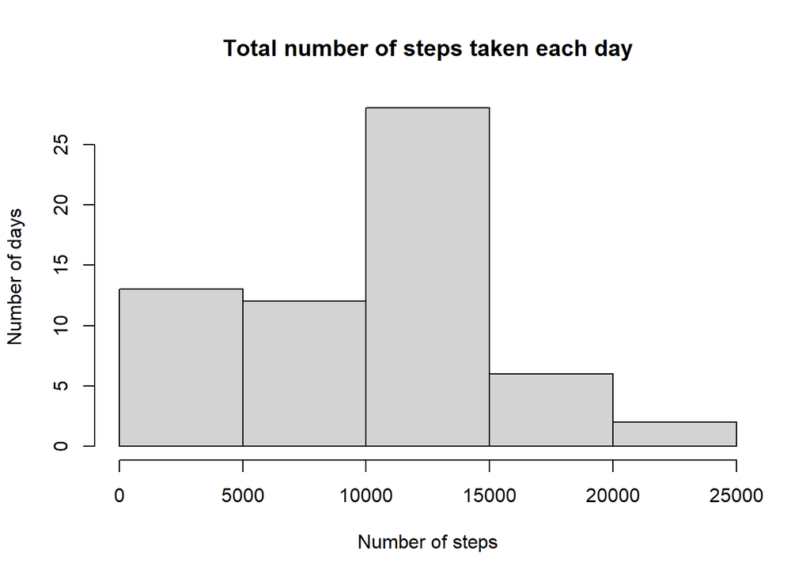

```r
library(dplyr)
y <- group_by(x, date)
means <-  summarise(y, mean(steps))
means[is.na(means)] <- 0

for(i in 1:nrow(x)){
  if(is.na(x$steps[i])){
    xx$steps[i] <- means$`mean(steps)`[means$date == xx$date]
  }
}

library(dplyr)
xx <- group_by(xx, date)
z <- summarise(xx, sum(steps))


hist(z$`sum(steps)`,  ylab = "Number of days", xlab = "Number of steps",
     main = "Total number of steps taken each day")
```

```r
meannmedian <- summarize(xx, mean(steps), median(steps))
meannmedian
```

```
## # A tibble: 61 x 3
##    date       `mean(steps)` `median(steps)`
##    <chr>              <dbl>           <dbl>
##  1 2012-10-01         0                   0
##  2 2012-10-02         0.438               0
##  3 2012-10-03        39.4                 0
##  4 2012-10-04        42.1                 0
##  5 2012-10-05        46.2                 0
##  6 2012-10-06        53.5                 0
##  7 2012-10-07        38.2                 0
##  8 2012-10-08         0                   0
##  9 2012-10-09        44.5                 0
## 10 2012-10-10        34.4                 0
## # ... with 51 more rows
```

## 8. Panel plot comparing the average number of steps taken per 5-minute interval across weekdays and weekends

```r
setwd("D:/Akhil/course_era/R/C5/W2")
x <- read.csv("activity.csv")
xx <- x
head(x)
```

steps date interval 1 NA 2012-10-01 0 2 NA 2012-10-01 5 3 NA 2012-10-01 10 4 NA 2012-10-01 15 5 NA 2012-10-01 20 6 NA 2012-10-01 25

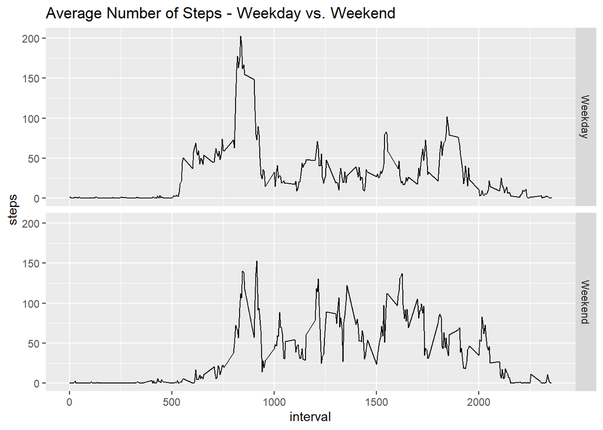

```r
library(dplyr)
y <- group_by(x, date)
means <-  summarise(y, mean(steps))
means[is.na(means)] <- 0

for(i in 1:nrow(x)){
  if(is.na(x$steps[i])){
    xx$steps[i] <- means$`mean(steps)`[means$date == xx$date]
  }
}

xx[,2] <- as.Date(x[,2])
#isWeekend(xx[,2])])
zz <- list()
library(dplyr)
library(RcppQuantuccia)
for(i in 1:nrow(xx)){
  zz[i] <- isWeekend(xx[i,2])
}

for(i in 1:nrow(xx)){
  mutate(xx, weekends = zz[i])
}

xx$day <- weekdays(xx[,2])

xx[,4] <- gsub(c('Monday'), 'Weekday', xx[,4])
xx[,4] <- gsub(c( 'Tuesday'), 'Weekday', xx[,4])
xx[,4] <- gsub(c( 'Wednesday'), 'Weekday', xx[,4])
xx[,4] <- gsub(c('Thursday'), 'Weekday', xx[,4])
xx[,4] <- gsub(c( 'Friday'), 'Weekday', xx[,4])
xx[,4] <- gsub(c('Saturday'), 'Weekend', xx[,4])
xx[,4] <- gsub(c('Sunday'), 'Weekend', xx[,4])


averages <- aggregate(steps ~ interval + day, data = xx, mean)


qplot(interval, steps, data = averages, facets = day ~ .,
      main = "Average Number of Steps - Weekday vs. Weekend",
      geom = 'line')
```